# The Result of Benchmarking a Hierarchical Clustering

## Experiment 1: Slaves x 2

### EC2 Environment

I run the hierarchical clustering application on EC2.

### Experimental Setup

You know, we have to run the application under another condisions for benchmarking. For example, changing the number of used cores and the number of dimensions.

### The Result of Training Execution Time

Under the number of rows is 10000000 and the number of clusters is 100, I could not run my application, maybe because of SPARK-3106.

[output not shown]

[output not shown]

[output not shown]

[output not shown]

[output not shown]

| numClusters | trainMilliSec | dimension | rows | numPartitions | sec |
| --- | --- | --- | --- | --- | --- |
| 5 | 23915 | 100 | 1e+05 | 192 | 23.91 |
| 10 | 37879 | 100 | 1e+05 | 192 | 37.88 |
| 20 | 62682 | 100 | 1e+05 | 192 | 62.68 |
| 50 | 134075 | 100 | 1e+05 | 192 | 134.07 |
| 100 | 245742 | 100 | 1e+05 | 192 | 245.74 |
| 5 | 49803 | 100 | 1e+06 | 192 | 49.80 |
| 10 | 115263 | 100 | 1e+06 | 192 | 115.26 |
| 20 | 252856 | 100 | 1e+06 | 192 | 252.86 |
| 50 | 647256 | 100 | 1e+06 | 192 | 647.26 |
| 100 | 1294181 | 100 | 1e+06 | 192 | 1294.18 |
| 5 | 475103 | 100 | 1e+07 | 192 | 475.10 |
| 10 | 1043169 | 100 | 1e+07 | 192 | 1043.17 |
| 20 | 2333825 | 100 | 1e+07 | 192 | 2333.82 |
| 50 | 5350811 | 100 | 1e+07 | 192 | 5350.81 |
| 100 | NA | 100 | 1e+07 | 192 | NA |

Where `numClusters` is the number of clusters gotten, `trainMilliSec` is the execution time for training in millisecond, `dimension` is the number of dimensions of the vectors which are treated in the clustering algorithm, `rows` is the number of trained vectors, `numPartitions` is the number of partitions of a RDD, `sec` is the execution time for training in second.

## Experiment 2: Slaves x 5

### EC2 Environment

I run the hierarchical clustering application on EC2.

### Experimental Setup

I execute my hierarchical clustering, changing the some parameters as bellow. The data had been generated randomly. And then I measured the execution time for training each model.

- # Used Cores: 160
- # Clusters: 5, 10, 20, 50, 100
- # Rows: 100000, 500000, 1000000, 5000000, 10000000
- # Dimensions: 100

### The Result of Training Execution Time

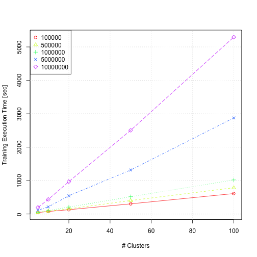

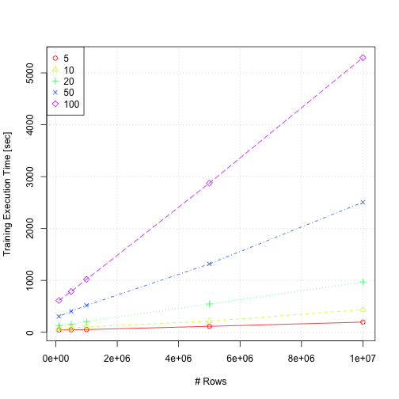

| maxCores | numClusters | trainMilliSec | dimension | rows | numPartitions | sec |
| --- | --- | --- | --- | --- | --- | --- |
| 160 | 5 | 44305 | 100 | 1e+05 | 160 | 44.30 |
| 160 | 10 | 75142 | 100 | 1e+05 | 160 | 75.14 |
| 160 | 20 | 129138 | 100 | 1e+05 | 160 | 129.14 |
| 160 | 50 | 304085 | 100 | 1e+05 | 160 | 304.08 |
| 160 | 100 | 612354 | 100 | 1e+05 | 160 | 612.35 |
| 160 | 5 | 46531 | 100 | 5e+05 | 160 | 46.53 |
| 160 | 10 | 86115 | 100 | 5e+05 | 160 | 86.11 |
| 160 | 20 | 155304 | 100 | 5e+05 | 160 | 155.30 |
| 160 | 50 | 404183 | 100 | 5e+05 | 160 | 404.18 |
| 160 | 100 | 785669 | 100 | 5e+05 | 160 | 785.67 |
| 160 | 5 | 52008 | 100 | 1e+06 | 160 | 52.01 |
| 160 | 10 | 102838 | 100 | 1e+06 | 160 | 102.84 |
| 160 | 20 | 207935 | 100 | 1e+06 | 160 | 207.94 |
| 160 | 50 | 517648 | 100 | 1e+06 | 160 | 517.65 |
| 160 | 100 | 1019953 | 100 | 1e+06 | 160 | 1019.95 |
| 160 | 5 | 114237 | 100 | 5e+06 | 160 | 114.24 |
| 160 | 10 | 214596 | 100 | 5e+06 | 160 | 214.60 |
| 160 | 20 | 545350 | 100 | 5e+06 | 160 | 545.35 |
| 160 | 50 | 1317012 | 100 | 5e+06 | 160 | 1317.01 |
| 160 | 100 | 2875260 | 100 | 5e+06 | 160 | 2875.26 |
| 160 | 5 | 196206 | 100 | 1e+07 | 160 | 196.21 |
| 160 | 10 | 436107 | 100 | 1e+07 | 160 | 436.11 |
| 160 | 20 | 969607 | 100 | 1e+07 | 160 | 969.61 |
| 160 | 50 | 2505698 | 100 | 1e+07 | 160 | 2505.70 |
| 160 | 100 | 5293639 | 100 | 1e+07 | 160 | 5293.64 |

Where `maxCores` is the number of execution cores on Apache Spark,`numClusters` is the number of clusters gotten, `trainMilliSec` is the execution time for training in millisecond, `dimension` is the number of dimensions of the vectors which are treated in the clustering algorithm, `rows` is the number of trained vectors, `numPartitions` is the number of partitions of a RDD, `sec` is the execution time for training in second.

## Experiment 3: About cores

- Object: Check the efficient of the number of cores

### EC2 Environment

I run the hierarchical clustering application on EC2.

### The Result of Training Execution Time

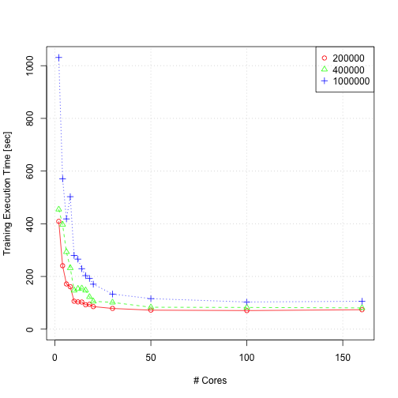

| maxCores | numClusters | trainMilliSec | dimension | rows | numPartitions | sec |
| --- | --- | --- | --- | --- | --- | --- |
| 2 | 10 | 409152 | 100 | 2e+05 | 2 | 409.15 |
| 4 | 10 | 240748 | 100 | 2e+05 | 4 | 240.75 |
| 6 | 10 | 171519 | 100 | 2e+05 | 6 | 171.52 |
| 8 | 10 | 161048 | 100 | 2e+05 | 8 | 161.05 |
| 10 | 10 | 106198 | 100 | 2e+05 | 10 | 106.20 |
| 12 | 10 | 103486 | 100 | 2e+05 | 12 | 103.49 |
| 14 | 10 | 102873 | 100 | 2e+05 | 14 | 102.87 |
| 16 | 10 | 92537 | 100 | 2e+05 | 16 | 92.54 |
| 18 | 10 | 94384 | 100 | 2e+05 | 18 | 94.38 |
| 20 | 10 | 85600 | 100 | 2e+05 | 20 | 85.60 |
| 30 | 10 | 78544 | 100 | 2e+05 | 30 | 78.54 |
| 50 | 10 | 72027 | 100 | 2e+05 | 50 | 72.03 |
| 100 | 10 | 70410 | 100 | 2e+05 | 100 | 70.41 |
| 160 | 10 | 73709 | 100 | 2e+05 | 160 | 73.71 |
| 2 | 10 | 454647 | 100 | 4e+05 | 2 | 454.65 |
| 4 | 10 | 397135 | 100 | 4e+05 | 4 | 397.13 |
| 6 | 10 | 293165 | 100 | 4e+05 | 6 | 293.17 |
| 8 | 10 | 232314 | 100 | 4e+05 | 8 | 232.31 |
| 10 | 10 | 147204 | 100 | 4e+05 | 10 | 147.20 |
| 12 | 10 | 153267 | 100 | 4e+05 | 12 | 153.27 |
| 14 | 10 | 155031 | 100 | 4e+05 | 14 | 155.03 |
| 16 | 10 | 147369 | 100 | 4e+05 | 16 | 147.37 |
| 18 | 10 | 122476 | 100 | 4e+05 | 18 | 122.48 |
| 20 | 10 | 105665 | 100 | 4e+05 | 20 | 105.67 |
| 30 | 10 | 101563 | 100 | 4e+05 | 30 | 101.56 |
| 50 | 10 | 83163 | 100 | 4e+05 | 50 | 83.16 |
| 100 | 10 | 82335 | 100 | 4e+05 | 100 | 82.33 |
| 160 | 10 | 80717 | 100 | 4e+05 | 160 | 80.72 |
| 2 | 10 | 1031158 | 100 | 1e+06 | 2 | 1031.16 |
| 4 | 10 | 570709 | 100 | 1e+06 | 4 | 570.71 |
| 6 | 10 | 418524 | 100 | 1e+06 | 6 | 418.52 |
| 8 | 10 | 502843 | 100 | 1e+06 | 8 | 502.84 |
| 10 | 10 | 279849 | 100 | 1e+06 | 10 | 279.85 |
| 12 | 10 | 265740 | 100 | 1e+06 | 12 | 265.74 |
| 14 | 10 | 229620 | 100 | 1e+06 | 14 | 229.62 |
| 16 | 10 | 203113 | 100 | 1e+06 | 16 | 203.11 |
| 18 | 10 | 192302 | 100 | 1e+06 | 18 | 192.30 |
| 20 | 10 | 170574 | 100 | 1e+06 | 20 | 170.57 |
| 30 | 10 | 133165 | 100 | 1e+06 | 30 | 133.16 |
| 50 | 10 | 115853 | 100 | 1e+06 | 50 | 115.85 |
| 100 | 10 | 103027 | 100 | 1e+06 | 100 | 103.03 |
| 160 | 10 | 105829 | 100 | 1e+06 | 160 | 105.83 |

Where `maxCores` is the number of execution cores on Apache Spark,`numClusters` is the number of clusters gotten, `trainMilliSec` is the execution time for training in millisecond, `dimension` is the number of dimensions of the vectors which are treated in the clustering algorithm, `rows` is the number of trained vectors, `numPartitions` is the number of partitions of a RDD, `sec` is the execution time for training in second.

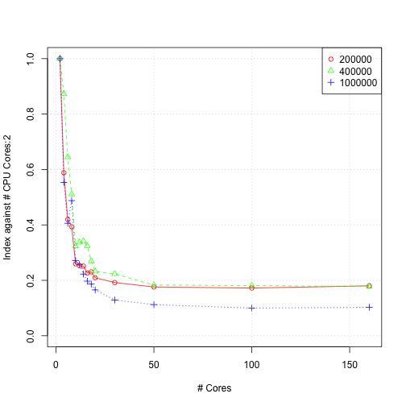

| x | 200000 | 400000 | 1000000 |
| --- | --- | --- | --- |
| 2.0000 | 1.0000 | 1.0000 | 1.0000 |
| 4.0000 | 0.5884 | 0.8735 | 0.5535 |
| 6.0000 | 0.4192 | 0.6448 | 0.4059 |
| 8.0000 | 0.3936 | 0.5110 | 0.4876 |
| 10.0000 | 0.2596 | 0.3238 | 0.2714 |
| 12.0000 | 0.2529 | 0.3371 | 0.2577 |
| 14.0000 | 0.2514 | 0.3410 | 0.2227 |
| 16.0000 | 0.2262 | 0.3241 | 0.1970 |
| 18.0000 | 0.2307 | 0.2694 | 0.1865 |
| 20.0000 | 0.2092 | 0.2324 | 0.1654 |
| 30.0000 | 0.1920 | 0.2234 | 0.1291 |
| 50.0000 | 0.1760 | 0.1829 | 0.1124 |
| 100.0000 | 0.1721 | 0.1811 | 0.0999 |
| 160.0000 | 0.1802 | 0.1775 | 0.1026 |

## Discussion

- The more the number of clusters which you want increases, the more the training execution time increases linearly.
- The more the number of input data rows increases, the more the training execution time increases linearly.
- The more the number of CPU cores on the Apache Spark cluster, the more the training execution time decrease. However if the number of CPU cores is large against the input data size, the time is saturant.

I feel that the algorithm was slower than I had expected. If possible, I want to decrease the execution time from at least 1/5 to 1/10.

## Appendix: Spark Cluster Environment

### Runtime Information

| Name | Value |
| --- | --- |
| Java Home | /usr/lib/jvm/java-1.7.0-openjdk-1.7.0.65.x86_64/jre |
| Java Version | 1.7.0_65 (Oracle Corporation) |
| Scala Version | version 2.10.4 |

#### Spark Properties

| Name | Value |
| --- | --- |
| spark.app.name | hierarchical clustering |
| spark.cores.max | 64 |
| spark.driver.host | ip-10-168-49-221.ap-northeast-1.compute.internal |
| spark.driver.port | 35853 |
| spark.executor.extraClassPath | /root/ephemeral-hdfs/conf |
| spark.executor.extraLibraryPath | /root/ephemeral-hdfs/lib/native/ |
| spark.executor.memory | 235520m |
| spark.fileserver.uri | http://10.168.49.221:42810 |
| spark.jars | file:/root/hierarchical-clustering-with-spark/target/scala-2.10/hierarchical-clustering_2.10-0.0.1.jar |
| spark.master | spark://ec2-54-95-186-78.ap-northeast-1.compute.amazonaws.com:7077 |
| spark.scheduler.mode | FIFO |
| spark.tachyonStore.folderName | spark-f418d485-90b6-4770-8694-d1721a07e5b6 |

### System Properties

[output not shown]

### Classpath Entries

| Resource | Source ▾ |
| --- | --- |
| http://10.168.49.221:42810/jars/hierarchical-clustering_2.10-0.0.1.jar | Added By User |
| /root/ephemeral-hdfs/conf | System Classpath |
| /root/ephemeral-hdfs/conf | System Classpath |
| /root/spark/conf | System Classpath |
| /root/spark/lib/datanucleus-api-jdo-3.2.1.jar | System Classpath |
| /root/spark/lib/datanucleus-core-3.2.2.jar | System Classpath |
| /root/spark/lib/datanucleus-rdbms-3.2.1.jar | System Classpath |
| /root/spark/lib/spark-assembly-1.1.0-hadoop2.0.0-mr1-cdh4.2.0.jar | System Classpath |